# Lab 3

Eric Steyer

3/5/2021

```r
data <- readxl::read_xls('/Users/Eric Steyer/Documents/DS 202/GSS.xls')
data <- data[0:64814,]
```

```r
names(data)[1] <- "year"
names(data)[2] <- "happy"
names(data)[3] <- "p_party"
names(data)[4] <- "race"
names(data)[5] <- "sex"
names(data)[6] <- "yr_school"
names(data)[7] <- "age"
names(data)[8] <- "marital"
names(data)[9] <- "id"
names(data)[10] <- "ballot"
```

```r
library(dplyr)
data$yr_school <- as.numeric(data$yr_school)
marital_school <- data %>% group_by(marital) %>% summarise(mean_school = mean(yr_school, na.rm=TRUE)) %>% arrange(desc(mean_school))

marital_school
```

```
## # A tibble: 6 x 2
##   marital       mean_school
##   <chr>               <dbl>
## 1 No answer            15.5
## 2 Never married        13.4
## 3 Divorced             13.1
## 4 Married              13.0
## 5 Separated            11.9
## 6 Widowed              11.2
```

Here we can see that the highest average years of school completed belongs to those people who didn’t answer if they were married. Married people seem to be in the middle, along with divorced people. Widowed people have gone to school the shortest amount of time on average.

```r
No_answer <- data %>% filter(marital == "No answer") %>% filter(yr_school>15.47826)

Nv_mar <- data %>% filter(marital == "Never married") %>% filter(yr_school>13.38954)

divorced <- data %>% filter(marital == "Divorced") %>% filter(yr_school>13.10582)

married <- data %>% filter(marital == "Married") %>% filter(yr_school>12.96828)

separated <- data %>% filter(marital == "Separated") %>% filter(yr_school>11.85580)

widowed <- data %>% filter(marital == "Widowed") %>% filter(yr_school>11.19825)

above <- do.call("rbind", list(No_answer,Nv_mar,divorced,married,separated,widowed))

str(above)
```

```
## Classes 'tbl_df', 'tbl' and 'data.frame':    30714 obs. of  10 variables:
##  $ year     : num  1990 1993 1994 1996 2006 ...
##  $ happy    : chr  "Pretty happy" "Very happy" "Don't know" "No answer" ...
##  $ p_party  : chr  "Other party" "Not str republican" "Ind,near rep" "Independent" ...
##  $ race     : chr  "White" "Black" "White" "White" ...
##  $ sex      : chr  "Female" "Male" "Female" "Female" ...
##  $ yr_school: num  17 18 16 19 19 18 16 16 16 17 ...
##  $ age      : chr  "74" "No answer" "74" "53" ...
##  $ marital  : chr  "No answer" "No answer" "No answer" "No answer" ...
##  $ id       : num  520 129 799 685 3211 ...
##  $ ballot   : chr  "Ballot a" "Ballot c" "Ballot a" "Ballot c" ...
```

```r
data$ishappy = data$happy == "Very happy" | data$happy=="Pretty happy"

data$ishappy = as.numeric(data$ishappy)

mar_happy = data %>% group_by(marital) %>% summarise(happypercent = mean(ishappy)) %>% arrange(desc(happypercent))

mar_happy
```

```
## # A tibble: 6 x 2
##   marital       happypercent
##   <chr>                <dbl>
## 1 Married              0.860
## 2 Never married        0.772
## 3 Widowed              0.754
## 4 Divorced             0.738
## 5 Separated            0.663
## 6 No answer            0.593
```

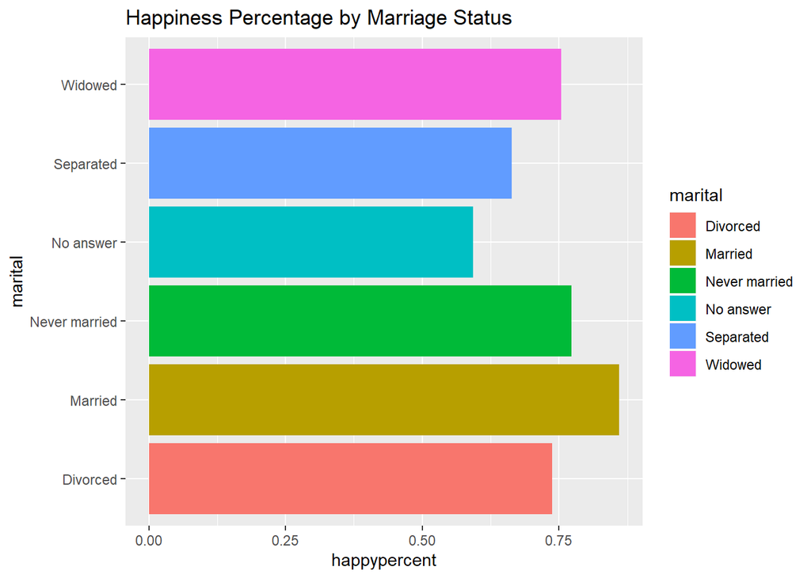

```r
library(ggplot2)
ggplot(mar_happy, aes(x=marital, y=happypercent, fill=marital)) + geom_bar(stat="identity") + ggtitle("Happiness Percentage by Marriage Status") + coord_flip()
```

Here I created a new variable, “ishappy”, which was 1 if they were “Very happy” or “Pretty happy”, and 0 otherwise. I then used that to find the percentage of people who were happy for each marital status. We can see from the results that the “No answer” and “Separated” have the smallest percentage of happy people, and Married people have the highest percentage of happy people.

```r
data2 = data %>% group_by(marital, p_party) %>% summarise(happypercent = mean(ishappy)) %>% arrange(desc(happypercent))

data2
```

```
## # A tibble: 58 x 3
## # Groups:   marital [6]
##    marital       p_party            happypercent
##    <chr>         <chr>                     <dbl>
##  1 Married       Don't know                1
##  2 No answer     Other party               1
##  3 Married       Not str republican        0.888
##  4 Married       Ind,near rep              0.876
##  5 Married       Not str democrat          0.866
##  6 Married       Strong republican         0.865
##  7 Married       Ind,near dem              0.860
##  8 Married       Other party               0.859
##  9 Married       Strong democrat           0.849
## 10 Never married Not str republican        0.821
## # ... with 48 more rows
```

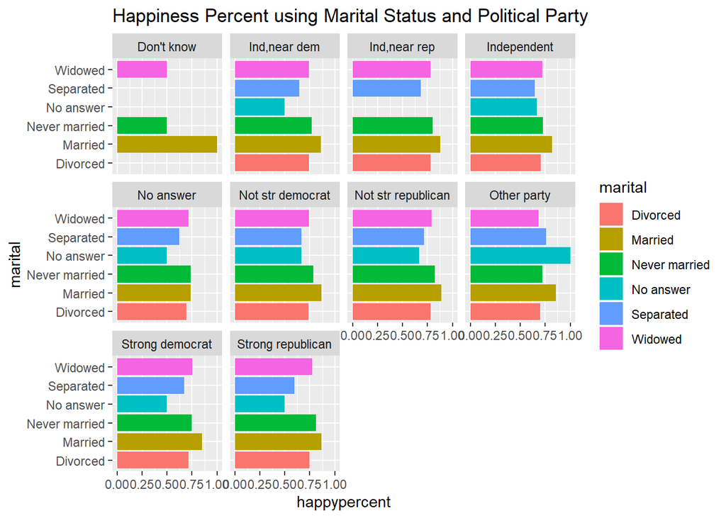

```r
ggplot(data2, aes(x=marital, y=happypercent, fill=marital)) + geom_bar(stat="identity") + facet_wrap(~p_party) + coord_flip() + ggtitle("Happiness Percent using Marital Status and Political Party")
```

In this problem, I grouped by marital status and political party. Married people still have the highest happiness percentages. It appears that “Other Party” and “Independent” political party individuals tend to have higher happiness percentages, but overall, the political parties don’t really affect the distibutions of happiness based on marital status.

```r
marital_school
```

```
## # A tibble: 6 x 2
##   marital       mean_school
##   <chr>               <dbl>
## 1 No answer            15.5
## 2 Never married        13.4
## 3 Divorced             13.1
## 4 Married              13.0
## 5 Separated            11.9
## 6 Widowed              11.2
```

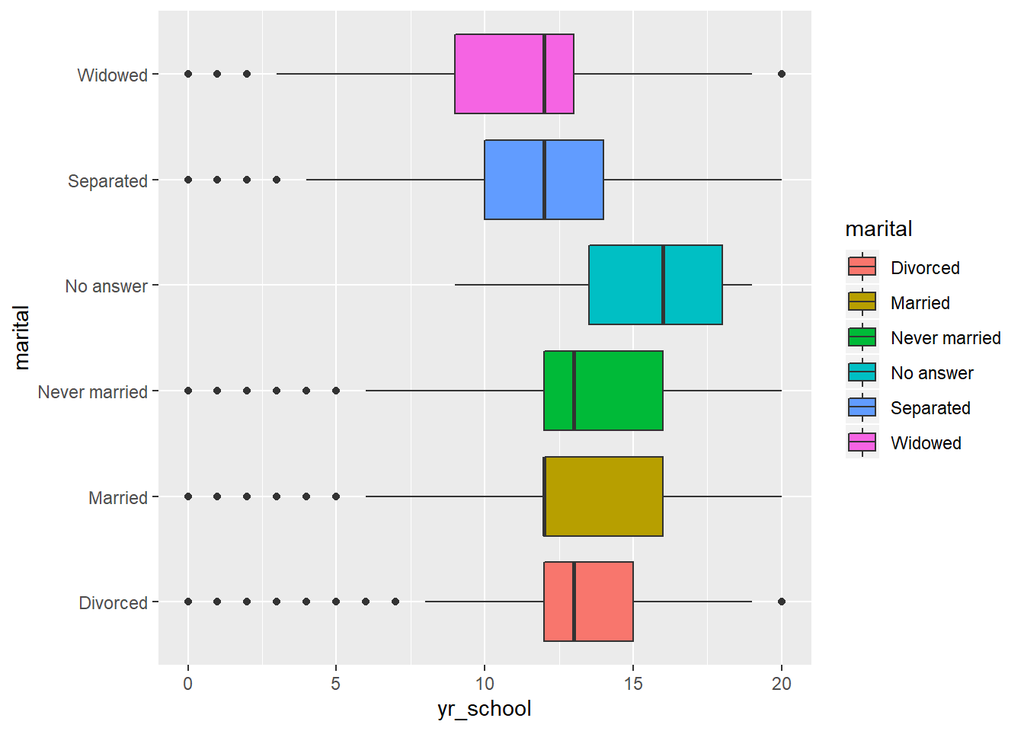

```r
ggplot(data, aes(x=marital, y=yr_school, fill=marital)) + geom_boxplot() + coord_flip()
```

Using the marital status and the years of school variable, we see that the “No answer” responses to marital status has the higher years of education. Widows and separated people seem to have the lowest years of education. A possible reason for this could be that people that go to school for a long time don’t want to reveal things about their private life, and maybe widows and separated people might drop out of school if they are still going to try to get a job.

```r
race_sex_happiness <- data %>% group_by(sex, race) %>% summarise(happypercent = mean(ishappy)) %>% arrange(desc(happypercent))

race_sex_happiness
```

```
## # A tibble: 6 x 3
## # Groups:   sex [2]
##   sex    race  happypercent
##   <chr>  <chr>        <dbl>
## 1 Female White        0.828
## 2 Male   White        0.825
## 3 Male   Other        0.763
## 4 Female Other        0.740
## 5 Male   Black        0.728
## 6 Female Black        0.725
```

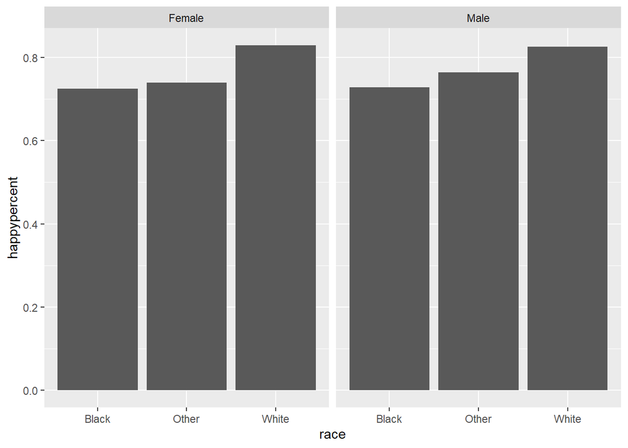

```r
ggplot(race_sex_happiness, aes(x=race, y=happypercent)) + geom_bar(stat="identity") + facet_wrap(~sex)
```

A question I wanted to answer was, How do race and sex affect a person’s happiness? I used the race, sex, and happiness variables. Here, we can see that White people seem to be the happiest, follwed by Other, then Black. There isn’t much of a difference between the sexes, except for “Other” race, where Men seem to be slightly happier.

```r
race_sex_school <- data %>% group_by(sex, race) %>% summarise(mean_school = mean(yr_school, na.rm=TRUE)) %>% arrange(desc(mean_school))

race_sex_school
```

```
## # A tibble: 6 x 3
## # Groups:   sex [2]
##   sex    race  mean_school
##   <chr>  <chr>       <dbl>
## 1 Male   White        13.2
## 2 Female White        12.9
## 3 Male   Other        12.7
## 4 Female Other        12.6
## 5 Female Black        12.2
## 6 Male   Black        11.9
```

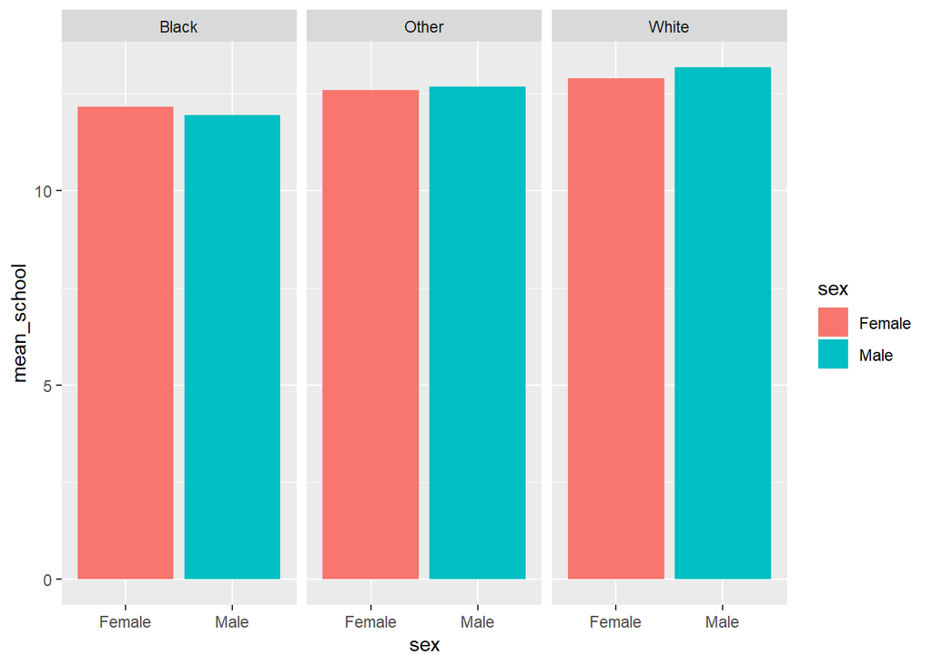

```r
ggplot(race_sex_school, aes(x=sex, y=mean_school, fill = sex)) + geom_bar(stat="identity") + facet_wrap(~race)
```

Then, I wanted to look at, How does race and sex affect the years of education for a person? I used the race, sex, and yr_school variables. Here, I found that White people had the most years in school, followed by Other, then Black. This follows the pattern for happiness. For White people and Other, males tend to go to school for a little longer, while for Black people, females tend to go for a little longer.